# Twitter Study on 2016 Election

## Introduction

Social media is now an essential part of modern era and people have become used to share their thoughts and opinions on social media such as [Twitter](https://twitter.com/) and [LinkedIn](https://www.linkedin.com/). In this exploratory and preliminary study, we use the approximately 1 million tweets collected between Oct. 19th, 7:30pm and Oct. 20th, 1:30am to try and predict the presidential election outcome. Note that the debate started ~9:00pm on Oct. 19th. In addition to providing more insights on how the social media reacts to the presidential debate, this study also serves as an exploration on the performance of `Word2Vec` module in [Apache Spark](https://spark.apache.org/)'s `spark.ml` package.

## Method

### Computing Infrastructure

The calculations were carried out on a homogeneous (`Intel(R) Core(TM) i7-2600 CPU @ 3.40GHz`) stand-alone Spark cluster consisting of a master node (2 cpu, 4GB RAM) and two slave nodes (8 cpu, 6GB RAM), which are all running [Scientific Linux 6](https://www.scientificlinux.org) as the operating system. Since this minimal cluster was temporarily built for performing this study using the desktop computers in my office, no job scheduler, such as [YARN](https://hadoop.apache.org/docs/r2.7.2/hadoop-yarn/hadoop-yarn-site/YARN.html) and [Mesos](http://mesos.apache.org/) was used. The actual `Spark` application is this `Jupyter Notebook`, which can be considered as a `PySpark` shell.__

__In this study, tweets gathered directly via [Twitter Streaming API](https://dev.twitter.com/streaming/overview) are in `JSON` format and each tweet may have dramatically different fields. Hence flexibility on schema design is important in choosing the database for warehousing and serving the collected tweets. [MongoDB](https://www.mongodb.com/) is a NoSQL database, which provides flexibility on the schema. Although it is also highly scalable and secure via sharding and replica sets, in this study one single MongoDB instance is sufficient considering the data size and streaming bandwidth limit imposed by Twitter.

### Text Mining

All the tweets are separated into two sections: before the 3rd presidential debate and in/post the debate. Technology wise, `Python` is used as the main programming language and standard `Python` tools, such as `NumPy` and `Pandas`, are used for data munging. Usually on twitter, people tend to use abbreviated words and phrases, which makes the text cleaning a challenge. So here [`NLTK`](http://http://www.nltk.org/index.html) was used for word stemming and stop-word removal. The tweets text was analyzed using `Word2Vec` NLP algorithm (skip-gram model) and `KMeans` clustering algorithm. Finally, the data visualization is carried out using [`plotly`](https://plot.ly/) and [`ggplot`](http://ggplot.yhathq.com). Note that both `Word2Vec` and `KMeans` were carried out using [Apache Spark](https://spark.apache.org/)'s `spark.ml` package. For querying the result and performing window aggregation, both its `DataFrame` API and standard `SQL` were used.

In this study, we only selected the original tweets as the sample, assuming that the distribution of political opinions within original tweets can correctly reflect that among all voters. We also only took the tweets in English for the simplicity of NLP process. The word vector length was set to be 100, which is a typical value for short documents. The number of clusers was set to be 5 here for this preliminary study.

## Result and Discussion

As shown below, `KMeans` calculation converged after considering 100 "features" generated in `Word2Vec` process. By comparing individual word vectors and actual tweet text with the vectors of centroids, we give the description of the 5 categories for both pre-debate and in/post-debate as:

|  | Pre-Debate | In/Post-Debate |
| --- | --- | --- |
| Category 0 | Neutral: Ads/Reports | Neutral: Expressing frustration on this election |
| Category 1 | Neutral: Unbiased comments | Slightly Supporting Clinton |
| Category 2 | Slightly Supporting Trump | Against Trump |
| Category 3 | Neutral: Reports | Neutral: Reports |
| Category 4 | Slightly Supporting Clinton | Slightly Supporting Trump |

According to the visualization, the number of tweets supporting Hillary Clinton is more than that supporting Donald Trump. This means that this study predicts Hillary Clinton is going to win this presidential election. Interestingly the visualization also shows that as the time approached the start of the 3rd presidential debate, more and more people became "neutral" or "undecided". However, after the debate started, more people "made choice", meaning both Trump and Clinton gained more supporters but Clinton still had more supporters.

Although our NLP model (`Word2Vec + KMeans`) predicts Hillary Clinton as the winner of this election, the aggregation study of the most popular hashtags showed different outcome. As shown below, the number of tweets that have hashtags supporting Trump is larger than that of the tweets which has hashtags supporting Clinton. This difference indicates that our NLP model may not be accurate enough and it needs more hyperparameter tuning (e.g. word vector length, number of `KMeans` clusters, etc.) and more careful text cleaning. It is interesting that roughly our current model can differentiate neutral opinions versus slightly biased opinions, but more categories may need to be added considering people's political view are quite complex.

## Code and Procedures

### Create A Connection To MongoDB

```python
import pymongo
from pymongo import MongoClient
client = MongoClient('mongodb://152.3.169.27:27017/')
```

```python
import numpy as np, scipy as sp
import pandas as pd
from pandas import DataFrame as df, Series as ss
import sklearn as sk
import ggplot, seaborn as sns
from pyspark.sql.types import *
from pyspark.sql.functions import *
%matplotlib inline
import random, string
```

```python
import re
from bs4 import BeautifulSoup
import nltk
from nltk.corpus import stopwords
from nltk.stem import PorterStemmer
ps = PorterStemmer()
```

```python
tweets = client['db_third_debate']
pre_debate = tweets['pre_debate']
in_debate = tweets['in_debate']
```

```python
pre_debate.find({"retweeted_status":{"$exists": False}}).count()
```

```
114544
```

```python
in_debate.find({"retweeted_status":{"$exists": False}}).count()
```

```
303731
```

### We Take Only The Original Tweets

```python
pre_debate_tweets = pd.DataFrame(list(pre_debate.find({"retweeted_status":{"$exists": False}},
         projection={"_id": False, "text": True, "lang": True, "timestamp_ms": True, "user['location']": True, \
                     "retweet_count": True, "entities.hashtags.text": True})) )
pre_debate_tweets = pre_debate_tweets.dropna(how='any', subset=['text'])
```

```python
in_debate_tweets = pd.DataFrame(list(in_debate.find({"retweeted_status":{"$exists": False}},
         projection={"_id": False, "text": True, "lang": True, "timestamp_ms": True, "user['location']": True, \
                     "retweet_count": True, "entities.hashtags.text": True})) )
in_debate_tweets = in_debate_tweets.dropna(how='any', subset=['text'])
```

```python
pre_debate_tweets['timestamp_ms'] = pre_debate_tweets['timestamp_ms'].astype(np.int)
pre_debate_tweets['retweet_count'] = pre_debate_tweets['retweet_count'].astype(np.int)
pre_debate_tweets['tweet'] = pre_debate_tweets['text']
in_debate_tweets['timestamp_ms'] = in_debate_tweets['timestamp_ms'].astype(np.int)
in_debate_tweets['retweet_count'] = in_debate_tweets['retweet_count'].astype(np.int)
in_debate_tweets['tweet'] = in_debate_tweets['text']
```

```python
pre_sample = random.sample(range(0, pre_debate_tweets.shape[0]), 25000)
in_sample = random.sample(range(0, in_debate_tweets.shape[0]), 25000)
```

```python
# pre_debate_tweets_sample = pre_debate_tweets.iloc[pre_sample].copy()
pre_debate_tweets_sample = pre_debate_tweets[pre_debate_tweets['lang']=="en"].copy()
```

```python
pre_debate_tweets_sample.shape
```

```
(83095, 6)
```

```python
# in_debate_tweets_sample = in_debate_tweets.iloc[in_sample].copy()
in_debate_tweets_sample = in_debate_tweets[in_debate_tweets['lang']=="en"].copy()
```

```python
in_debate_tweets_sample.shape
```

```
(209463, 6)
```

### Cleaning The Text

```python
class cleanTweets(object):

    acc = 0
    stops = set(stopwords.words("english"))

    @classmethod
    def clearText(self, textString):
        '''
        @param textString: String
        '''
        # Back to plain string
        # s1 = str(textString.decode('unicode_escape').encode('ascii','ignore'))

        if type(textString) == 'float':
            textString = str(textString)
        s1 = str(textString.encode('ascii', 'ignore'))
        # Remove URLs
        s1 = re.sub(r'http[s]?://(?:[a-zA-Z]|[0-9]|[$-_@.&+]|[!*\(\),]|(?:%[0-9a-fA-F][0-9a-fA-F]))+', ' ', s1)
        # Remove @...s
        s1 = re.sub(r'@\w+\b', ' ', s1)
        # Remove hashtags, we will check hash tags later from tweet fields
        s1 = re.sub(r'#\w+\b', ' ', s1)
        # Punctuations, special treatment for "U.S."
        s1 = re.sub(r'U\.S\.', 'US', s1)
        # s1 = re.sub(r'[\"\'\`\,\.\-\:\{\}\!\?\<\>\[\]]|\&amp\;|\\n', ' ', s1)
        s1 = s1.translate(None, string.punctuation)

        # Apply NLTK
        # s1 = ' '.join(nltk.word_tokenize(s1)).strip()
        s1 = nltk.word_tokenize(s1)
        words = [ps.stem(w.lower()) for w in s1 if not w.lower() in self.stops ]

        # lowerCaseWords = [w.lower() for w in words]
        self.acc = self.acc + 1
        # print self.acc

        # return ' '.join(lowerCaseWords)
        # return lowerCaseWords
        return words

    @classmethod
    def collectHashTags(self, thisEntities):
        j = []
        for tag in thisEntities['hashtags']:
            j.append(str(tag[u'text'].encode('ascii', 'ignore')))
        self.acc = self.acc + 1
        return j
```

```python
cleanTweets.acc = 0
```

```python
pre_debate_tweets_sample['text'] = pre_debate_tweets_sample['text'].apply(cleanTweets.clearText)
```

```python
in_debate_tweets_sample['text'] = in_debate_tweets_sample['text'].apply(cleanTweets.clearText)
```

```python
pre_debate_tweets_sample['entities'] = pre_debate_tweets_sample['entities'].apply(cleanTweets.collectHashTags)
in_debate_tweets_sample['entities'] = in_debate_tweets_sample['entities'].apply(cleanTweets.collectHashTags)
```

### Start SparkSession

```python
# spark.conf.set('spark.executor.memory', '6G')
```

```python
sp_pre_debate_tweets = spark.createDataFrame(pre_debate_tweets_sample)
sp_pre_debate_tweets.cache()
sp_in_debate_tweets = spark.createDataFrame(in_debate_tweets_sample)
sp_in_debate_tweets.cache()

sp_pre_debate_tweets = sp_pre_debate_tweets.withColumnRenamed('entities', 'hashtags')
sp_in_debate_tweets = sp_in_debate_tweets.withColumnRenamed('entities', 'hashtags')
```

### Applying the `pyspark.ml.feature.Word2Vec` and `pyspark.ml.clustering.KMeans`

```python
from pyspark.ml.feature import Word2Vec
word2Vec = Word2Vec(vectorSize=100, minCount=5, inputCol="text", outputCol="word_vector")
```

```python
w2v_pre_model = word2Vec.fit(sp_pre_debate_tweets)
w2v_in_model = word2Vec.fit(sp_in_debate_tweets)
```

```python
w2v_pre_result = w2v_pre_model.transform(sp_pre_debate_tweets)
w2v_pre_result.cache()
w2v_in_result = w2v_in_model.transform(sp_in_debate_tweets)
w2v_in_result.cache()
```

```
DataFrame[hashtags: array<string>, lang: string, retweet_count: bigint, text: array<string>, timestamp_ms: bigint, tweet: string, word_vector: vector]
```

```python
from pyspark.ml.clustering import KMeans
kmeans = KMeans(featuresCol="word_vector", predictionCol="prediction", k=5, seed=1023)
kmeans_pre_model = kmeans.fit(w2v_pre_result)
kmeans_in_model = kmeans.fit(w2v_in_result)
```

```python
trans_w2v_pre_results = kmeans_pre_model.transform(w2v_pre_result)
trans_w2v_in_results = kmeans_in_model.transform(w2v_in_result)
```

### Performing Window Aggregation On Prediction

```python
trans_w2v_pre_results = trans_w2v_pre_results.withColumn('time',
                                 from_unixtime(trans_w2v_pre_results['timestamp_ms']/1000)).sort('time')
trans_w2v_in_results = trans_w2v_in_results.withColumn('time',
                                 from_unixtime(trans_w2v_in_results['timestamp_ms']/1000)).sort('time')
```

```python
trans_w2v_pre_results = trans_w2v_pre_results.withColumn('grid',
                                                         window(trans_w2v_pre_results['time'], "20 minute"))
trans_w2v_in_results = trans_w2v_in_results.withColumn('grid',
                                                         window(trans_w2v_in_results['time'], "30 minute"))
```

```python
trans_w2v_pre_results_sql = trans_w2v_pre_results.createOrReplaceTempView("pre_result")

trans_w2v_in_results_sql = trans_w2v_in_results.createOrReplaceTempView("in_result")
```

```python
pre_result_window = spark.sql("""
  SELECT prediction, COUNT(prediction) AS _count, grid.start
  FROM pre_result
  GROUP BY prediction, grid.start
  ORDER BY prediction, grid.start
""")

pre_result_pdf = pre_result_window.toPandas()

in_result_window = spark.sql("""
  SELECT prediction, count(prediction) AS _count, grid.start
  FROM in_result
  GROUP BY prediction, grid.start
  ORDER BY prediction, grid.start
""")

in_result_pdf = in_result_window.toPandas()
```

### Visualization on Percentages using `plotly` and `cufflinks`

```python
pre_time = list(pre_result_pdf['start'].unique())
in_time = list(in_result_pdf['start'].unique())
pre_count = []
in_count = []
for itime in pre_time:
    pre_count.append(pre_result_pdf[pre_result_pdf['start']==itime]['_count'].sum())
for itime in in_time:
    in_count.append(in_result_pdf[in_result_pdf['start']==itime]['_count'].sum())
```

```python
pre_result_pdf['percentage'] = pre_result_pdf['_count']
in_result_pdf['percentage'] = in_result_pdf['_count']
for index, row in pre_result_pdf.iterrows():
    pre_result_pdf.loc[index, 'percentage'] = float(row['_count']) / \
    float(pre_count[pre_time.index(np.datetime64(row['start']))])
    # print float(row['_count']) / float(pre_count[row['prediction']])
for index, row in in_result_pdf.iterrows():
    in_result_pdf.loc[index, 'percentage'] = float(row['_count']) / \
    float(in_count[in_time.index(np.datetime64(row['start']))])
```

```python
import cufflinks as cf
print cf.__version__
import plotly.plotly as py
```

```
0.8.2
```

```python
pre_result_pdf_pivot = pre_result_pdf.pivot('start', 'prediction')['percentage']
in_result_pdf_pivot = in_result_pdf.pivot('start', 'prediction')['percentage']
```

```python
pre_result_pdf_pivot.index
```

```
DatetimeIndex(['2016-10-19 19:20:00', '2016-10-19 19:40:00',
               '2016-10-19 20:00:00', '2016-10-19 20:20:00',
               '2016-10-19 20:40:00', '2016-10-19 21:00:00'],
              dtype='datetime64[ns]', name=u'start', freq=None)
```

```python
cf.set_config_file(offline=True, world_readable=True, theme='ggplot')
pre_result_pdf_pivot.iplot(kind='barh',barmode='stack', bargap=.3, filename='cf_pre_debate')
```

[interactive chart not shown]

```python
cf.set_config_file(offline=True, world_readable=True, theme='ggplot')
in_result_pdf_pivot.iplot(kind='barh',barmode='stack', bargap=.3, filename='cf_in_debate')
```

[interactive chart not shown]

### What are they ???

```python
for category in range(5):
    print "# ===========> Category {0} <=========== #".format(category)
    trans_w2v_pre_results.filter(trans_w2v_pre_results['prediction']==category).select('tweet').show(10, False)
```

```
# ===========> Category 0 <=========== #
+------------------------------------------------------------------------------------------------------------------------------------------------+
|tweet                                                                                                                                           |
+------------------------------------------------------------------------------------------------------------------------------------------------+
|U.S. Presidential candidates, @HillaryClinton &amp;  @realDonaldTrump in final face-off tonight.Follow the #debate live https://t.co/lHByDNmC5X"|
|Another presidential debate come on tonight...ugh                                                                                               |
|Palin to be a Trump guest at tonight's debate https://t.co/GBflmHqCQ7 https://t.co/0IhxUb85GA                                                   |
|Palin to be a Trump guest at tonight's debate https://t.co/P3QQgVuDmM https://t.co/Xj4bv4j4Cv                                                   |
|Palin to be a Trump guest at tonight's debate https://t.co/Nnu3IQfsl7 https://t.co/7OIO6uobCV                                                   |
|{UAH} Unshackled Trump and confident Clinton to clash in final presidential debate: Donald… https://t.co/V7g2qLr00O                             |
|Trump, Clinton gear up for final face-off: Donald Trump heads into his final debate clash with Hillary Clinto... https://t.co/K7dbCGSMia        |
|Palin to be a Trump guest at tonight's debate https://t.co/QiAkX0J6Hq https://t.co/sRupGiLghx                                                   |
|Palin to be a Trump guest at tonight's debate https://t.co/LhxiCcwEmW https://t.co/71KOaqJ7zB                                                   |
|Nigel Farage: Trump To Destroy Hillary in Final Debate https://t.co/8hUFp34ZWP via @YouTube                                                     |
+------------------------------------------------------------------------------------------------------------------------------------------------+
only showing top 10 rows

# ===========> Category 1 <=========== #
+----------------------------------------------------------------------------------------------------------------------------------------+
|tweet                                                                                                                                   |
+----------------------------------------------------------------------------------------------------------------------------------------+
|#ImWithHer and will be watching the final #debate LIVE on Twitter tonight! https://t.co/86mASjefW0 https://t.co/Y7uwwm6d8p              |
|#ImWithHer and will be watching the final #debate LIVE on Twitter tonight! https://t.co/n7nVOy7GDl https://t.co/przN7Onw39              |
|#ImWithHer and will be watching the final #debate LIVE on Twitter tonight! https://t.co/LJgCm9pD46 https://t.co/ZnyhpiYJ1m              |
|#ImWithHer and will be watching the final #debate LIVE on Twitter tonight! https://t.co/cOviT4ULfQ https://t.co/hsCKpjaQch              |
|#TRUMP2016 #MAGA  #TRUMP #TRUMPTRAIN #NEVERHILLARY #CROOKEDHILLARY #CLINTONSCANDALS #BASEMENTDWELLERS WATCH NOW! https://t.co/4zcW8Zrt4M|
|I'm on the #TrumpTrain and will be watching the final #debate LIVE on Twitter tonight! https://t.co/kozh4wJR59 https://t.co/w9rXu5AOgb  |
|I'll be watching the final #Debate streaming LIVE on Twitter tonight at https://t.co/SaEqh0VQgP.
https://t.co/jm7mH9qb7o                |
|I'm on the #TrumpTrain and will be watching the final #debate LIVE on Twitter tonight! https://t.co/98yOzoHgOm https://t.co/xMmroaa4Q4  |
|#ImWithHer and will be watching the final #debate LIVE on Twitter tonight! https://t.co/A9UqPqvRsF https://t.co/HS7MLm2k78              |
|I'm on the #TrumpTrain and will be watching the final #debate LIVE on Twitter tonight! https://t.co/q34PCIkuYH https://t.co/1gNCJwVZbN  |
+----------------------------------------------------------------------------------------------------------------------------------------+
only showing top 10 rows

# ===========> Category 2 <=========== #
+--------------------------------------------------------------------------------------------------------------------------------------------+
|tweet                                                                                                                                       |
+--------------------------------------------------------------------------------------------------------------------------------------------+
|'Bowl of Skittles' photographer sues Trumps, Pence     - CNET: Lawsuit alleges Trump campaign did not have pe... https://t.co/Z6CuAFSfcq    |
```

[output cut: 32 more lines]

```
+--------------------------------------------------------------------------------------------------------------------------------------------+
|Fox Chapel doctor’s anti-Trump yard signs have a distinct Pittsburgh flavor https://t.co/mKTRJC9UIU                                         |
|This makes marginally less sense than the half-brother thing. https://t.co/Os8hYBUJcP                                                       |
|@RealDJTrumpTeam Trump strong. Go Trump                                                                                                     |
|⚡️ “Bernie's Best Trump Takedowns” by @BernieSanders

https://t.co/wjDaDMBU45                                                               |
|@BretBaier @megynkelly @FoxNews   Trump hating crew there Bret.                                                                             |
|Hillary could have sewn up election if she invited Alec Baldwin dressed as #Trump to sit in front row #debatenight                          |
|And Van says they are booing Trump...just then they break into "LOCK HER UP! LOCK HER UP" 😂 #Debate #DrainTheSwamp https://t.co/cp51TJgyH8 |
|@LouDobbs poor #cnn, been listening on radio pre #debatenight to see if they have changed? NOPE still same bies led… https://t.co/6GYtuADBcf|
|I HIGHLY DOUBT THAT.  He is another @FoxNews Trump hater. https://t.co/ABdQuljJ1N                                                           |
|REPPIN! https://t.co/ZI4sz0bMB9                                                                                                             |
+--------------------------------------------------------------------------------------------------------------------------------------------+
only showing top 10 rows
```

```python
for category in range(5):
    print "# ===========> Category {0} <=========== #".format(category)
    trans_w2v_in_results.filter(trans_w2v_in_results['prediction']==category).select('tweet').show(10, False)
```

```
# ===========> Category 0 <=========== #
+------------------------------------------------------------------------------------------------------------------------------------------+
|tweet                                                                                                                                     |
+------------------------------------------------------------------------------------------------------------------------------------------+
|#cornmeal crusted #redsnapper and #fries. #fishandchips #presidentialdebate #worstelectionever… https://t.co/6xRxmXDBQM                   |
|Eck. Did it have to start with the F-word? #fauxnews #debatenight                                                                         |
|Only 90 more minutes guys! #wegotthis #debates                                                                                            |
|@dan5656 @Aaron_RS I have a major disagreement with her on Trump.  Glad she survived cancer, obviously.  Cheap shot.                      |
|I want to die. #debatenight                                                                                                               |
|Clinton needs to ensure she remains presidential and pivot herself towards policy not playing politics with @realDonaldTrump  #debatenight|
|Fix my student loan problem #debatenight                                                                                                  |
|Open discussion? This is about to be MAYHEM. #debatenight                                                                                 |
|We know that a wreck is certain, but the train has left the station regardless. #debatenight                                              |
|@weeklystandard It matters to 40+ million people. How insulting. #debate https://t.co/265zT4JaDO                                          |
+------------------------------------------------------------------------------------------------------------------------------------------+
only showing top 10 rows

# ===========> Category 1 <=========== #
+----------------------------------------------------------------------------------------------------------------------------------------+
|tweet                                                                                                                                   |
+----------------------------------------------------------------------------------------------------------------------------------------+
|Who do I vote for? #debatenight                                                                                                         |
|I just told @nbcwashington who I think is winning. Cast your vote now! #Debates #NBC4DC https://t.co/Ap20jEuq62                         |
|@Couples_Coop what do you think? https://t.co/vAm0heQW94                                                                                |
|@cnni @HillaryClinton wins! @CNNLIVE_ #debate https://t.co/vdNZrQtZ0S                                                                   |
|Who you voting for? #debatenight                                                                                                        |
|@jk_rowling What do you think about the #debatenight                                                                                    |
|He has my vote. https://t.co/BopShVNyaJ                                                                                                 |
|I just told @nbcwashington who I think is winning. Cast your vote now! #Debates #NBC4DC https://t.co/EwPfcQIMr3                         |
|#Debate...@HillaryClinton is winning! #Trump #FeelTheBern @HillaryClinton @GovGaryJohnson @DrJillStein #DumpTrump #NeverTrump #HRC #Bern|
|I just told @nbcwashington who I think is winning. Cast your vote now! #Debates #NBC4DC https://t.co/vRGzFtlx04                         |
+----------------------------------------------------------------------------------------------------------------------------------------+
only showing top 10 rows

# ===========> Category 2 <=========== #
+-----------------------------------------------------------------------------------------------------------------------------------------+
|tweet                                                                                                                                    |
+-----------------------------------------------------------------------------------------------------------------------------------------+
|End them all. https://t.co/JxHKv3OfLj                                                                                                    |
|DONALD TRUMP FC #debatenight                                                                                                             |
```

[output cut: 30 more lines]

```
+--------------------------------------------------------------------------------------------------------------------------------------+
|tweet                                                                                                                                 |
+--------------------------------------------------------------------------------------------------------------------------------------+
|Reuters US: FOREX-Dollar steady as investors await U.S. presidential debate, ECB https://t.co/rlEsBqOGQf                              |
|Watching the Usa Presidential debate.... not from the usa and i am stressed out!                                                      |
|It figures the last Presidential debate would be in Sin City. #prophetic #debatenight                                                 |
|I'm on the #TrumpTrain and will be watching the final #debate LIVE on Twitter tonight! https://t.co/56PQyZ52lc https://t.co/8QUAz1RPjN|
|Awake to watch the final. I expect fireworks #debatenight                                                                             |
|@In2TheSunshine2 And the Presidential Debate is on. #debate                                                                           |
|WATCH: The Third 2016 Presidential Debate (LIVE STREAM) https://t.co/NVbOGwixem https://t.co/eXVM4oGkLe                               |
|Me watching the #debates https://t.co/dCXFmnb67k                                                                                      |
|WATCH: The Third 2016 Presidential Debate (LIVE STREAM) https://t.co/tSZXHIGdPg https://t.co/r5pnmxmVaF                               |
|watching the presidential debate 2016                                                                                                 |
+--------------------------------------------------------------------------------------------------------------------------------------+
only showing top 10 rows
```

### Top Ten Word

```python
pre_debate_words = []
for index, row in pre_debate_tweets_sample.iterrows():
    pre_debate_words.append(row['text'])
pre_debate_words_flat = [val for sublist in pre_debate_words for val in sublist]
```

```python
len(pre_debate_words_flat)
```

```
663585
```

```python
in_debate_words = []
for index, row in in_debate_tweets_sample.iterrows():
    in_debate_words.append(row['text'])
in_debate_words_flat = [val for sublist in in_debate_words for val in sublist]
```

```python
len(in_debate_words_flat)
```

```
1526647
```

```python
pre_debate_words_df = spark.createDataFrame(pd.DataFrame(pre_debate_words_flat, columns=['word']))
pre_debate_words_window = pre_debate_words_df.createOrReplaceTempView("pre_debate_words_window")
```

```python
spark.sql("""
  SELECT word, COUNT(word) AS count
  FROM pre_debate_words_window
  GROUP BY word
  ORDER BY count DESC
""").show(10)
```

```
+----------+-----+
|      word|count|
+----------+-----+
|     trump|44167|
|     debat|14081|
|presidenti| 9209|
|   tonight| 7812|
|    donald| 7652|
|     watch| 7429|
|     final| 7015|
|   clinton| 6738|
|   hillari| 6452|
|      live| 5518|
+----------+-----+
only showing top 10 rows
```

```python
in_debate_words_df = spark.createDataFrame(pd.DataFrame(in_debate_words_flat, columns=['word']))
in_debate_words_window = in_debate_words_df.createOrReplaceTempView("in_debate_words_window")
```

```python
spark.sql("""
  SELECT word, COUNT(word) AS count
  FROM in_debate_words_window
  GROUP BY word
  ORDER BY count DESC
""").show(10)
```

```
+----------+-----+
|      word|count|
+----------+-----+
|     trump|94843|
|     debat|22079|
|   hillari|21397|
|    donald|18828|
|   clinton|16445|
|       say|13824|
|presidenti|11677|
|      like|11443|
|      vote|10905|
|     elect|10347|
+----------+-----+
only showing top 10 rows
```

### Top Ten #HashTags

```python
pre_debate_tags = []
for index, row in pre_debate_tweets_sample.iterrows():
    pre_debate_tags.append(row['entities'])
pre_debate_tags_flat = [val for sublist in pre_debate_tags for val in sublist]
```

```python
in_debate_tags = []
for index, row in in_debate_tweets_sample.iterrows():
    in_debate_tags.append(row['entities'])
in_debate_tags_flat = [val for sublist in in_debate_tags for val in sublist]
```

```python
pre_debate_tags_df = spark.createDataFrame(pd.DataFrame(pre_debate_tags_flat, columns=['tags']))
pre_debate_tags_window = pre_debate_tags_df.createOrReplaceTempView("pre_debate_tags_window")
in_debate_tags_df = spark.createDataFrame(pd.DataFrame(in_debate_tags_flat, columns=['tags']))
in_debate_tags_window = in_debate_tags_df.createOrReplaceTempView("in_debate_tags_window")
```

```python
spark.sql("""
  SELECT tags, COUNT(tags) AS tag_count
  FROM pre_debate_tags_window
  GROUP BY tags
  ORDER BY tag_count DESC
""").show(30)
```

```
+--------------------+---------+
|                tags|tag_count|
+--------------------+---------+
|              debate|    14929|
|         debatenight|     7337|
|              Debate|     2771|
|               Trump|     2594|
|  PresidentialDebate|     1505|
|           ImWithHer|     1323|
|             debates|     1194|
|          TrumpTrain|     1128|
|             Hillary|      967|
|         DebateNight|      795|
|             Clinton|      617|
|                MAGA|      613|
|               trump|      595|
|       DrainTheSwamp|      498|
|      DebateHeadache|      481|
|          debate2016|      470|
|             Debates|      368|
|        Election2016|      350|
|         Debatenight|      306|
|          NeverTrump|      267|
|                 CNN|      235|
|         Debates2016|      234|
|MakeAmericaGreatA...|      201|
|                news|      197|
|        TrumpPence16|      196|
|      HillaryClinton|      193|
|         DonaldTrump|      180|
|RejectedHillarySl...|      175|
|                tcot|      172|
|                News|      141|
+--------------------+---------+
only showing top 30 rows
```

```python
print "pre-debate:\nTrump\t:\t{0}\nClinton\t:\t{1}".format(2594 + 1128 + 613 + 595 + 498 + 201 + 196 + 180 + 175,
                                                           1323 + 967 + 617 + 267 + 193)
```

```
pre-debate:
Trump	:	6180
Clinton	:	3367
```

```python
spark.sql("""
  SELECT tags, COUNT(tags) AS tag_count
  FROM in_debate_tags_window
  GROUP BY tags
  ORDER BY tag_count DESC
""").show(30)
```

```
+------------------+---------+
|              tags|tag_count|
+------------------+---------+
|       debatenight|    57764|
|            debate|    26002|
|       DebateNight|     6000|
|            Debate|     4744|
|             Trump|     4393|
|           Debates|     4263|
|           debates|     3523|
|            NBC4DC|     3446|
|       Debatenight|     2196|
|         ImWithHer|     2062|
|PresidentialDebate|     1922|
|           Hillary|     1708|
|        debate2016|     1239|
|             trump|     1154|
|              MAGA|     1048|
|    DebateHeadache|     1025|
|           Clinton|      801|
|       Debates2016|      761|
|         FactCheck|      715|
|     TrumpDebateCT|      703|
|             NBCCT|      694|
|    HillaryClinton|      659|
|       DonaldTrump|      620|
|      Election2016|      571|
|      ChrisWallace|      505|
|        NeverTrump|      502|
|     DrainTheSwamp|      472|
|         imwithher|      456|
|        TrumpTrain|      433|
|              news|      417|
+------------------+---------+
only showing top 30 rows
```

### More Visualizations using `ggplot` for offline view

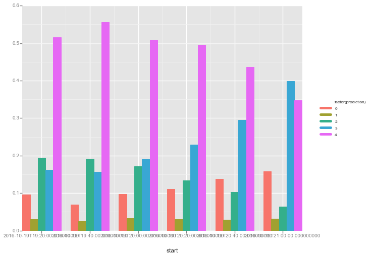

```python
ggplot.ggplot(pre_result_pdf, ggplot.aes(x='start', weight='percentage', fill='factor(prediction)')) \
+ ggplot.geom_bar()
```

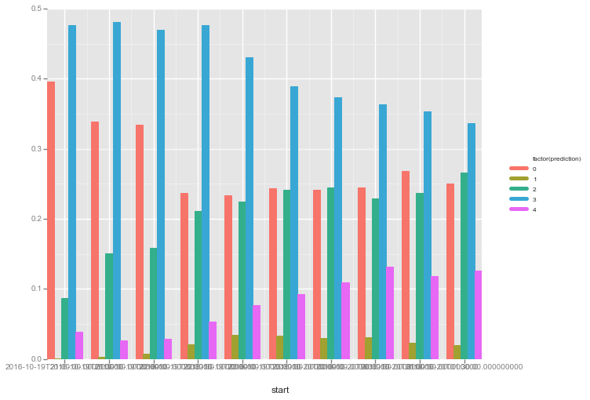

```python
ggplot.ggplot(in_result_pdf, ggplot.aes(x='start', weight='percentage', fill='factor(prediction)')) \
+ ggplot.geom_bar()
```